# Proyecto Data Science

José Alberto Félix Rodríguez

2020-11-12

El Proyecto de Data Science consiste en:

1)Planteamiento de preguntas del proyecto junto con un análisis exploratorio y una gráfica.

2)Entrenamiento del modelo de clasificación de KNN.

##### Entrenamiento del Modelo de Clasificación de KNN

Cargamos los paquetes a utilizar.

```r
require(class)
require(gmodels)
require(dplyr)
```

```r
library(ggplot2)
library(tidyverse)
library(dplyr)
```

Abrimos las bases de datos que utilizaremos y las guardamos en una variable:

```r
dbv <- "C:\\Users\\Beto Felix\\Desktop\\Beto\\SPPC\\Curso Análisis de Datos\\klustera\\v.csv"
dbe <- "C:\\Users\\Beto Felix\\Desktop\\Beto\\SPPC\\Curso Análisis de Datos\\klustera\\e.csv"

## Guardar base de datos en variable
e <- read.csv(paste(dbe, sep="/"), stringsAsFactors = FALSE)
v <- read.csv(paste(dbv, sep="/"), stringsAsFactors = FALSE)
```

```r
str(e)
```

```
## 'data.frame':    249556 obs. of  9 variables:
##  $ X             : int  1 2 3 4 5 6 7 8 9 10 ...
##  $ device_mac    : chr  "00:00:00:6a:17:ce" "00:00:00:6a:17:ce" "00:00:00:6a:78:ae" "00:00:02:fa:9c:12" ...
##  $ branch_office : int  1 1 1 1 3 3 2 3 1 1 ...
##  $ month_tz      : int  11 11 10 11 11 11 11 11 11 11 ...
##  $ day_tz        : int  2 2 30 13 4 3 4 5 19 8 ...
##  $ day_of_week_tz: chr  "Wednesday" "Wednesday" "Sunday" "Sunday" ...
##  $ hour_tz       : int  0 1 20 12 19 5 19 17 16 11 ...
##  $ visitor       : chr  "true" "true" "false" "true" ...
##  $ tiempodeses   : int  2676 2676 0 2272 0 0 0 0 0 0 ...
```

```r
e <- e[-1]
str(e)
```

```
## 'data.frame':    249556 obs. of  8 variables:
##  $ device_mac    : chr  "00:00:00:6a:17:ce" "00:00:00:6a:17:ce" "00:00:00:6a:78:ae" "00:00:02:fa:9c:12" ...
##  $ branch_office : int  1 1 1 1 3 3 2 3 1 1 ...
##  $ month_tz      : int  11 11 10 11 11 11 11 11 11 11 ...
##  $ day_tz        : int  2 2 30 13 4 3 4 5 19 8 ...
##  $ day_of_week_tz: chr  "Wednesday" "Wednesday" "Sunday" "Sunday" ...
##  $ hour_tz       : int  0 1 20 12 19 5 19 17 16 11 ...
##  $ visitor       : chr  "true" "true" "false" "true" ...
##  $ tiempodeses   : int  2676 2676 0 2272 0 0 0 0 0 0 ...
```

Verificamos que no haya datos NA en la base de datos “e”

```r
sapply(e, function(x) sum(is.na(x)))
```

```
##     device_mac  branch_office       month_tz         day_tz day_of_week_tz
##              0              0              0              0              0
##        hour_tz        visitor    tiempodeses
##              0              0              0
```

Cambiamos a factor la columna de visitor y convertimos su contenido en Visitante y No Visitante. También sacamos en porcentaje cuántos Visitantes y cuántos No Visitantes hay

```r
e$visitor <- factor(e$visitor, levels = c("true", "false"),
                    labels = c("Visitante", "No Visitante"))

round(prop.table(table(e$visitor)) * 100, digits = 1)
```

```
##
##    Visitante No Visitante
##         34.2         65.8
```

Exploramos los valores de los atributos que tienen un mínimo y un máximo muy separados entre si y normalizamos esos valores.

```r
summary(e[c("tiempodeses", "day_tz", "hour_tz")])
```

```
##   tiempodeses        day_tz        hour_tz
##  Min.   :    0   Min.   : 1.0   Min.   : 0.00
##  1st Qu.:    0   1st Qu.: 7.0   1st Qu.:10.00
##  Median :    0   Median :13.0   Median :14.00
##  Mean   : 2375   Mean   :14.8   Mean   :13.64
##  3rd Qu.:  421   3rd Qu.:24.0   3rd Qu.:18.00
##  Max.   :68062   Max.   :31.0   Max.   :23.00
```

```r
normalize <- function(x) {
  return ((x - min(x)) / (max(x) - min(x)))
}

e_n <- as.data.frame(lapply(e[c(4,6,8)], normalize)) #list apply
head(e_n)
```

```
##       day_tz    hour_tz tiempodeses
## 1 0.03333333 0.00000000  0.03931709
## 2 0.03333333 0.04347826  0.03931709
## 3 0.96666667 0.86956522  0.00000000
## 4 0.40000000 0.52173913  0.03338133
## 5 0.10000000 0.82608696  0.00000000
## 6 0.06666667 0.21739130  0.00000000
```

Separamos la base de datos en un database de prueba y en otro de entrenamiento, guardando la clasificación que tuvieron en otra variable.

```r
nfilas <- floor(nrow(e_n) * .80)
set.seed(123)
index <- sample(7:nrow(e_n), nfilas) # 80%
e_train <- e_n[1:80000, ] # Obtener solo las muestras
e_test <- e_n[80001:90000, ] # Todo menos las muestras

# Guardamos la clasificaciÃ³n de cada uno (B o M) de la primera columna
e_train_labels <- e[1:80000, 7]
e_test_labels <- e[80001:90000, 7]
str(e_train_labels)
```

```
##  Factor w/ 2 levels "Visitante","No Visitante": 1 1 2 1 2 2 2 2 2 2 ...
```

Se realiza la predicción con un número de veces que se analizara siendo “K” ese número y realizamos una tabla para verificar el resultado de nuestra predicción.

```r
e_test_pred <- knn(train = e_train, test = e_test, cl = e_train_labels, k = 30)

## ----------- Evaluamos los resultados del modelo
# Creamos una tabla para compara predicciones vs real
CrossTable(x = e_test_labels, y = e_test_pred, prop.r=FALSE, prop.chisq = FALSE)
```

```
##
##
##    Cell Contents
## |-------------------------|
## |                       N |
## |           N / Col Total |
## |         N / Table Total |
## |-------------------------|
##
##
## Total Observations in Table:  10000
##
##
##               | e_test_pred
## e_test_labels |    Visitante | No Visitante |    Row Total |
## --------------|--------------|--------------|--------------|
##     Visitante |         2714 |          806 |         3520 |
##               |        0.995 |        0.111 |              |
##               |        0.271 |        0.081 |              |
## --------------|--------------|--------------|--------------|
##  No Visitante |           15 |         6465 |         6480 |
##               |        0.005 |        0.889 |              |
##               |        0.002 |        0.646 |              |
## --------------|--------------|--------------|--------------|
##  Column Total |         2729 |         7271 |        10000 |
##               |        0.273 |        0.727 |              |
## --------------|--------------|--------------|--------------|
##
##
```

Agregamos la predicción a la base “v” en una nueva columna llamada “Visitor”

```r
v$visitor <- e_test_pred
summary(v$visitor)
```

```
##    Visitante No Visitante
##        24561        65439
```

##### ¿Cuál es el mes con mayor número de visitantes?

Para sacar el mes con el mayor número de visitantes, primero se realizará un filtro sobre la columna “Visitor” para dejar solo los valores con “Visitantes”. Luego se agrupara por mes y por último, se contará los registros que salieron en las agrupaciones.

```r
mes <- v %>%
  filter(visitor=="Visitante") %>%
  group_by(month_tz) %>%
  count() %>%
  mutate(total=n)
```

Se obtiene los siguientes datos:

```r
mes
```

```
## # A tibble: 2 x 3
## # Groups:   month_tz [2]
##   month_tz     n total
##      <int> <int> <int>
## 1       10  3031  3031
## 2       11 21530 21530
```

Se realiza la gráfica de los datos anteriores

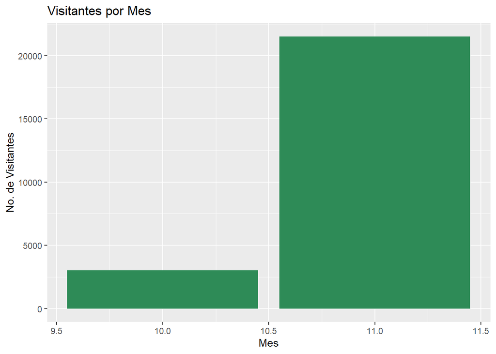

```r
gr <- ggplot(mes, aes(x=month_tz, y=total)) +
  geom_col(fill="seagreen")+labs(title = "Visitantes por Mes", x="Mes", y="No. de Visitantes")
gr
```

###### ¿Cuál es el día de la semana con mayor número de visitantes?

Para sacar el día de la semana con el mayor número de visitantes, primero se realizará un filtro sobre la columna “Visitor” para dejar solo los valores con “Visitantes”. Luego se agrupara por día y por último, se contará los registros que salieron en las agrupaciones.

```r
 dia <- v %>%
  filter(visitor=="Visitante") %>%
  group_by(day_of_week_tz) %>%
  count() %>%
  mutate(total=n)
```

Se obtiene los siguientes datos:

```r
dia
```

```
## # A tibble: 7 x 3
## # Groups:   day_of_week_tz [7]
##   day_of_week_tz     n total
##   <chr>          <int> <int>
## 1 Friday          2580  2580
## 2 Monday          3545  3545
## 3 Saturday        2941  2941
## 4 Sunday          2465  2465
## 5 Thursday        4049  4049
## 6 Tuesday         4102  4102
## 7 Wednesday       4879  4879
```

Se realiza la gráfica de los datos anteriores

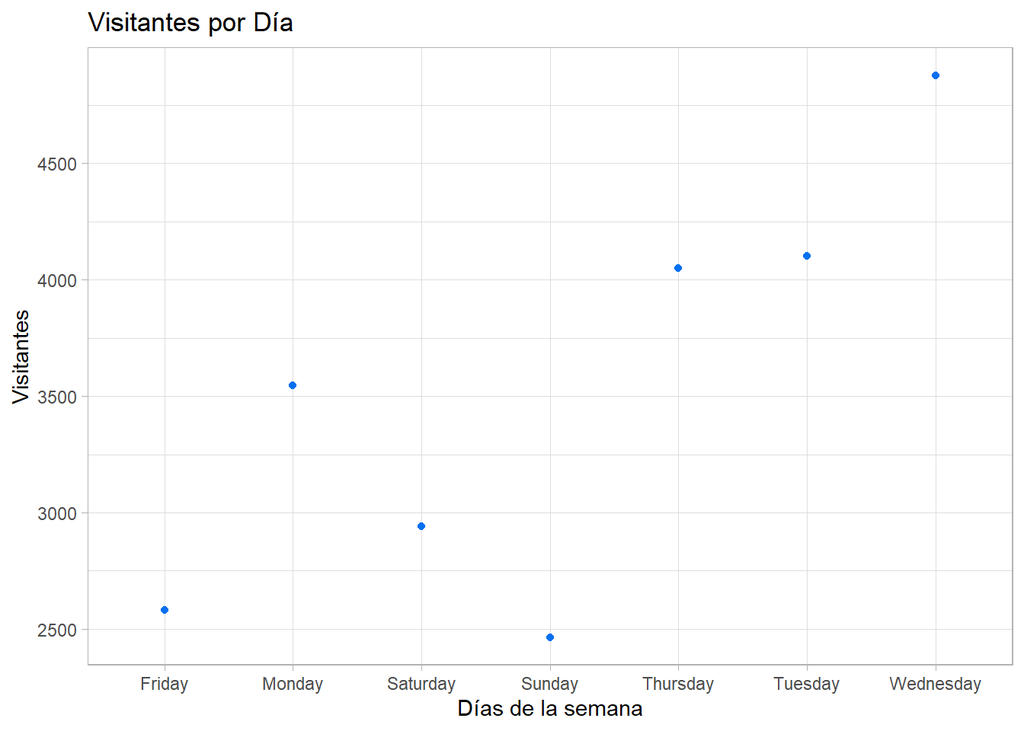

```r
gr <- ggplot(dia, aes(x=day_of_week_tz, y=total)) +
  geom_point(color="#0570F1")+ labs(title = "Visitantes por Día",x="Días de la semana",y="Visitantes")+
  theme_light()
gr
```

##### ¿Cuál es la franquicia que cuenta con el mayor número de visitantes?

Para sacar la franquicia que obtuvo el mayor número de visitantes, primero se realizará un filtro sobre la columna “Visitor” para dejar solo los valores con “Visitantes”. Luego se agrupara por franquicia y por último, se contará los registros que salieron en las agrupaciones.

```r
branch <- v %>%
  filter(visitor=="Visitante") %>%
  group_by(branch_office) %>%
  count() %>%
  mutate(total=n)
```

Se obtiene los siguientes datos:

```r
branch
```

```
## # A tibble: 3 x 3
## # Groups:   branch_office [3]
##   branch_office     n total
##           <int> <int> <int>
## 1             1 12541 12541
## 2             2  2382  2382
## 3             3  9638  9638
```

Se realiza la gráfica de los datos anteriores

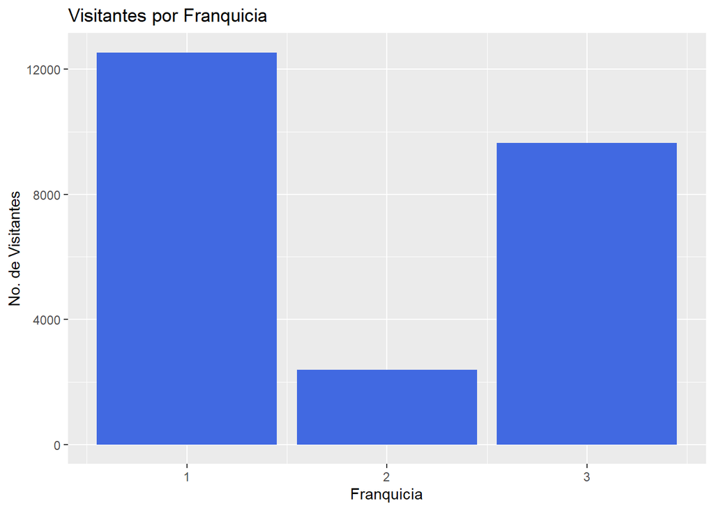

```r
gr <- ggplot(branch, aes(x=branch_office, y=total)) +
  geom_col(fill="royalblue")+labs(title = "Visitantes por Franquicia", x="Franquicia", y="No. de Visitantes")
gr
```